# Statistical inference with the GSS data

## Setup

### Load packages

```r
library(ggplot2)
library(dplyr)
library(statsr)
```

### Load data

```r
load("gss.Rdata")
```

## Part 1: Data

Causality cannot be established when comparing any variables to each-other because this is an observational study. However this sample data can be used to examine association / correlations between variables.

## Part 2: Research question

There appears to be a global trend of increasing educational level over time: https://ourworldindata.org/global-rise-of-education#attainment-by-level

So it would be interesting to know if the USA is also following the global general trend seen around the world. The null hypothesis used in this study is that there is no relationship between the two categorical variables year (“year”) and level of educational attainment (“degree”).

According to this link given above “Education is widely accepted to be a fundamental resource, both for individuals and societies….Education at higher levels, mainly secondary and tertiary, is becoming increasingly important around the world” this is a motivation for selecting these variables for study.

## Part 3: Exploratory data analysis

To tally up the counts for the two categorical variables “year” and “degree”" I use the table command to examine the numbers in the dataset. Note that the lowest cell count is 17 (see Inference section cell must have at least 5 cases as a condition for Chi Squared Independence Test).

Summary Statistics:

The code below creates for tbl_deg_year creates a count of year by degree type:

```r
tbl_deg_year <- table(gss$year, gss$degree)
tbl_deg_year
```

```
##
##        Lt High School High School Junior College Bachelor Graduate
##   1972            587         762             17      124       52
##   1973            510         720             20      132       65
##   1974            479         722             25      139       73
##   1975            492         732             33      140       50
##   1976            482         728             24      152       61
##   1977            488         741             34      139       74
##   1978            431         804             42      151       62
##   1980            407         745             45      158       71
##   1982            539         938             74      165       84
##   1983            385         835             61      202       80
##   1984            374         764             54      175       77
##   1985            387         795             60      175       90
##   1986            376         750             48      192       80
```

[output cut: 16 more lines]

This shows the proportion of each type across all the samples in the dataset which will be used to calculated the expected values for the Chi Squared Test:

```r
prop.deg <- colMeans(tbl_deg_year)/sum(colMeans(tbl_deg_year))
prop.deg
```

```
## Lt High School    High School Junior College       Bachelor       Graduate
##     0.21091506     0.52250629     0.05477155     0.14276284     0.06904426
```

This prop.deg information above is used in the “Inference” Section later on in the analysis to manually calculate expected values as input to Chi squared for the Chi Squared independence test.

```r
year.total <- rowSums(tbl_deg_year)
year.total
```

```
## 1972 1973 1974 1975 1976 1977 1978 1980 1982 1983 1984 1985 1986 1987 1988
## 1542 1447 1438 1447 1447 1476 1490 1426 1800 1563 1444 1507 1446 1777 1453
## 1989 1990 1991 1993 1994 1996 1998 2000 2002 2004 2006 2008 2010 2012
## 1509 1353 1483 1575 2953 2874 2801 2779 2746 2794 4475 2008 2032 1966
```

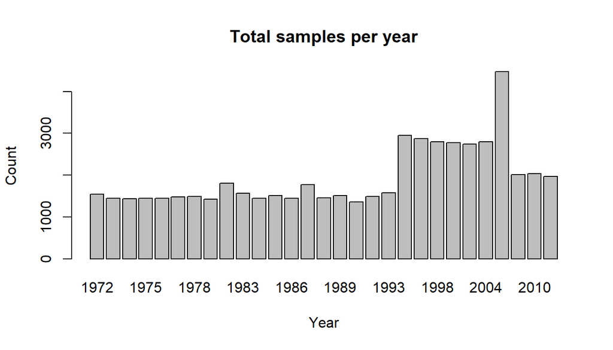

```r
barplot(year.total,xlab = "Year", ylab = "Count", main = "Total samples per year")
```

Cross-check: These absolute numbers match the expected levels in the http://gss.norc.org/Pages/Faq.aspx question “How many people are interviewed for each GSS?” and are as expected.

Following from the barplot above a more detailed visualisation of this data looks at the samples by degree and by year. The year is on the x-axis (explanatory) and the absolute count is on the y axis (response) variables.

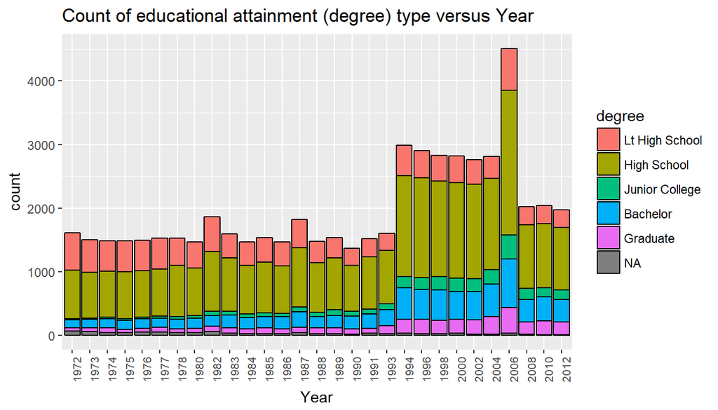

```r
ggplot(gss, aes(x = factor(year), ..count.. )) + geom_bar(aes(fill=degree), colour = "black") + labs(title="Count of educational attainment (degree) type versus Year", x = "Year") + theme(axis.text.x = element_text(size=8, angle=90))
```

The bar plot above indicates that there may be some differences but as the sample sizes are different from year to year but it is difficult to see the proportions of each degree level due to the changes in annual sample aggregates (1972-1993 vs 1994-2012).

To explore further the normalized barplot below is created to examine the proportional levels of education attained (degree) by year.

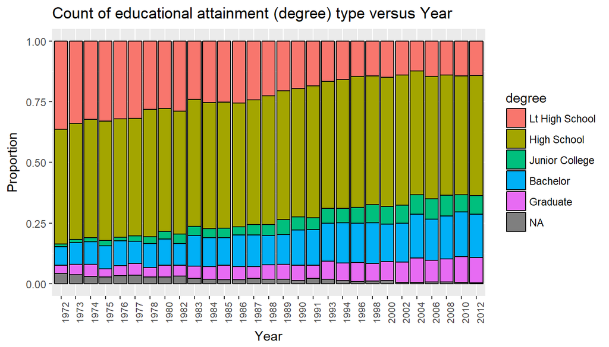

```r
ggplot(gss, aes(x = factor(year), ..count.. )) + geom_bar(aes(fill=degree), colour = "black", position = "fill") + labs(title="Count of educational attainment (degree) type versus Year", x = "Year", y = "Proportion") + theme(axis.text.x = element_text(size=8, angle=90))
```

This bar plot above shows the ratios using a normalised plot. Visually this plot indicates there is a difference in the proportions of educational attainment (degree) as this changes over the years. The year (year) is the explanatory variable (x-axis) and the educational attainment (degree) is the response variable (y-axis).

## Part 4: Inference

Hypothesis: This inference section examines the chi squared test of independence to confirm or reject the null hypothesis. The two selected random variables “year” and “degree” are called independent if the probability distribution of one variable is not affected by the presence of the other. The null hypothesis as stated in an earlier section is that there is no relationship (i.e. independence) between sampling year (“year”) and level of educational attainment (“degree”).

Conditions: Check for the conditions for the Chi-squared test:

1. Independence - YES
1. Sampled observations must be independent - YES
2. Random sample/assignment - YES
3. If sampling without replacement the sample must be less than 10% of the population - Yes
4. Each case only contributes one cell to a table - YES

2 Sample Size - each particular scenario a cell must have at least 5 expected cases (cell in the table “tbl_deg_year” - see EDA section table “tbl_deg_year”" the lowest value is 17) - YES

Method:

The method used for Inference in this study is the Chi Squared Test of Independence using R calculation chisq.test. I found the chisq.test function being applied to chi-squared tests (but NOT the GSS dataset or these variables) at the following source link: http://www.r-tutor.com/elementary-statistics/goodness-fit/chi-squared-test-independence

In addition to confirm the method above is correct I have also calculated Chi Squared “manually” (really semi-manually using some more step by step calculations in R) to evaluate the relationship between the two categorical variables “year”" and “degree”. It is performed on the (tbl_deg_year) set created and discussed in the Exploratory Data Analysis section.

Inference:

The chisq.test function in R is applied to the table tbl_deg_year extracted from GSS dataset and is shown as a table of numbers and visually explored in Part 3: Exploratory Data Analysis.

```r
chisq.test(tbl_deg_year)
```

```
##
##  Pearson's Chi-squared test
##
## data:  tbl_deg_year
## X-squared = 2910.3, df = 112, p-value < 2.2e-16
```

Check:

Note that from the “tbl_deg_year” created in the exploratory data analysis section we can see that there are 5 columns (degree) and 29 rows (year).

```r
unique(gss$year)
```

```
##  [1] 1972 1973 1974 1975 1976 1977 1978 1980 1982 1983 1984 1985 1986 1987
## [15] 1988 1989 1990 1991 1993 1994 1996 1998 2000 2002 2004 2006 2008 2010
## [29] 2012
```

```r
unique(gss$degree)
```

```
## [1] Bachelor       Lt High School High School    <NA>
## [5] Graduate       Junior College
## Levels: Lt High School High School Junior College Bachelor Graduate
```

The degrees of freedom calculated in a chi squared test of independence is df = (R - 1) x (C - 1) = (29 - 1) x (5 - 1) = 112 degrees of freedom. 29 years and 5 Degree levels.

Manual Check that Chi Squared Test is correct:

Below is a manual check of the R code above (not relying on the chisq.test function) and it follows the Duke lectures approach to calculate Chi squared for Independence manually. This section calculates the expected values based on the total expected values over all the years of data. The proportion from Part 3: EDA is copied in the next row here: prop.deg <- colMeans(tbl_deg_year)/sum(colMeans(tbl_deg_year)) and prop.deg is used to create the expected level in exp_matdf and tbl_exp in the R code below.

In this section a matrix and then dataframe is created from year.total as rows and prop.deg as columns multipliers matrix. “expected” is the year list repeated 5 times. “exp_mat” is the row totals repeated in 5 columns.

```r
expected <- rep(year.total, 5) #repeat the year total 5 times
exp_mat <- matrix(expected, nrow = 29, ncol=5,dimnames = list(rownames(tbl_deg_year),colnames(tbl_deg_year))) # create a matrix from the vector
# need to multiply each column by the correct proportion
exp_matdf <- as.data.frame(exp_mat)
#each expected column is calculated on per column basis in sequence prop.deg is the proportion of educational level across all years (see previous Exploratory Data Analysis)
exp_matdf$`Lt High School` <- exp_matdf$`Lt High School`*prop.deg[1]
exp_matdf$`High School` <- exp_matdf$`High School`*prop.deg[2]
exp_matdf$`Junior College` <- exp_matdf$`Junior College`*prop.deg[3]
exp_matdf$Bachelor <- exp_matdf$Bachelor*prop.deg[4]
exp_matdf$Graduate <- exp_matdf$Graduate*prop.deg[5]
exp_matdf <- round(exp_matdf,2) #round to two decimal places

#the expected count value is calculated for each
tbl_exp <- as.matrix(exp_matdf)
delta <- tbl_deg_year - tbl_exp #shows the difference between the actual value and the expected value
delta
```

```
##
##        Lt High School High School Junior College Bachelor Graduate
##   1972         261.77      -43.70         -67.46   -96.14   -54.47
##   1973         204.81      -36.07         -59.25   -74.58   -34.91
##   1974         175.70      -29.36         -53.76   -66.29   -26.29
##   1975         186.81      -24.07         -46.25   -66.58   -49.91
##   1976         176.81      -28.07         -55.25   -54.58   -38.91
##   1977         176.69      -30.22         -46.84   -71.72   -27.91
##   1978         116.74       25.47         -39.61   -61.72   -40.88
##   1980         106.24       -0.09         -33.10   -45.58   -27.46
##   1982         159.35       -2.51         -24.59   -91.97   -40.28
##   1983          55.34       18.32         -24.61   -21.14   -27.92
##   1984          69.44        9.50         -25.09   -31.15   -22.70
##   1985          69.15        7.58         -22.54   -40.14   -14.05
##   1986          71.02       -5.54         -31.20   -14.44   -19.84
```

[output cut: 16 more lines]

```r
element_chisq <- delta^2/tbl_exp
#the last line above is in preparation for the manual check against the equation
chi_sqsum <- sum(element_chisq)
chi_sqsum #this double checks the chi squared value manually using the matrix calculated in the exploratory data analysis section
```

```
## [1] 2910.336
```

The delta table shown above which shows the difference between the observed value and the expected value (Observed - Expected) which has been calculated using the R code above and rounded to two decimal places. Note the delta (not squared like Chi squared) is shown to give an indication that the changes are not random but appear to have a pattern.

Final Chi Squared calculation check:

Here the manually calculated value for Chisquare “chi_sqsum” is 2910 when I calculate delta using 2 decimal places and it gives the same value as the R calculated chisq.test = 2910.

Results interpretation:

This small p-value < 2.2e-16 means that the null hypothesis should be rejected in favour of the alternative hypothesis that there is a relationship between year and educational attainment level “degree”. This is however an observational study only and it is not possible to deduce a causal relationship. It is noted that the general trend to increasing higher levels of education is in line with Global trends - https://ourworldindata.org/global-rise-of-education#attainment-by-level.

Density Graph for Chi Square:

The very small p-value means that visually it is far to the right of the chi squared distrbution chart and so difficult to visualise as the number is so small. The chart looks something like this but the value of 2910.3 is far to the right of the chart and cannot be seen.

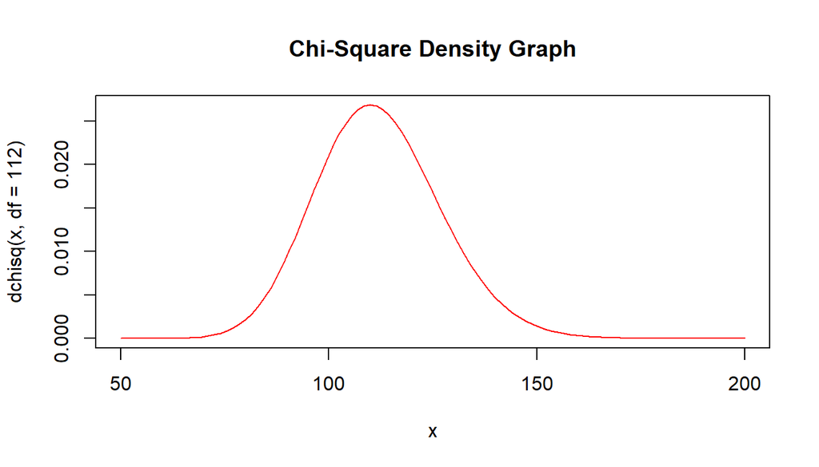

```r
x <- pchisq(2910.3, 112, lower.tail=FALSE)
curve( dchisq(x, df=112), col='red', main = "Chi-Square Density Graph",
          from=50,to=200 )
```

Only the right hand tail of the interval is relevant to the Chi Squared Test of Independence.